# Análisis Relacional entre los Eventos Sísmicos Ocurridos en Territorios Dominicano en el año 2014 y las Denominadas “Fallas Geológicas Mayores del País”; Análisis Geoestadístico de la Intensidad del S

## 3 Variograma muestral

Generacion de variogramas muestral para la intensidad del evento

```r
vsismo <- variogram(CDI~1, sismo[-3,])
vsismo
```

| np | dist | gamma | dir.hor | dir.ver | id |
| --- | --- | --- | --- | --- | --- |
| 3 | 4584.981 | 0.5350000 | 0 | 0 | var1 |
| 7 | 10025.756 | 0.4942857 | 0 | 0 | var1 |
| 13 | 16753.915 | 0.8142308 | 0 | 0 | var1 |
| 15 | 23283.776 | 0.7913333 | 0 | 0 | var1 |
| 25 | 29909.915 | 0.7958000 | 0 | 0 | var1 |
| 31 | 35425.649 | 0.6551613 | 0 | 0 | var1 |
| 23 | 41942.032 | 0.5152174 | 0 | 0 | var1 |
| 31 | 48821.493 | 0.6208065 | 0 | 0 | var1 |
| 28 | 55407.033 | 0.7028571 | 0 | 0 | var1 |
| 30 | 61686.614 | 0.6780000 | 0 | 0 | var1 |

[output cut: 5 more lines]

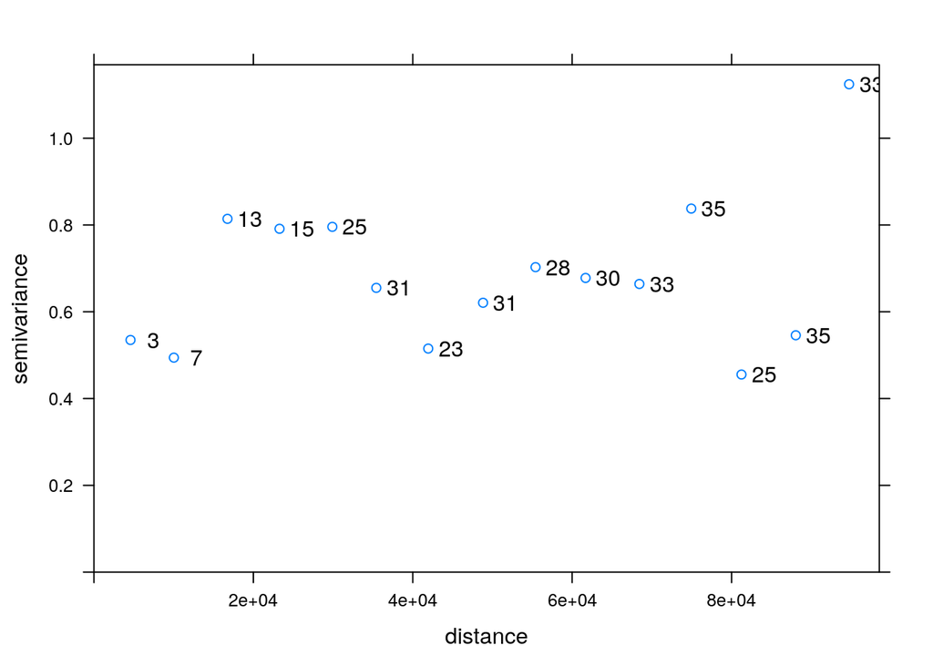

```r
plot(vsismo, plot.numbers = T)
```

```r
vsismolog <- variogram(CDIlog~1, sismo[-3,])
vsismolog
```

| np | dist | gamma | dir.hor | dir.ver | id |
| --- | --- | --- | --- | --- | --- |
| 3 | 4584.981 | 0.05667565 | 0 | 0 | var1 |
| 7 | 10025.756 | 0.05614854 | 0 | 0 | var1 |
| 13 | 16753.915 | 0.09676437 | 0 | 0 | var1 |
| 15 | 23283.776 | 0.11080402 | 0 | 0 | var1 |
| 25 | 29909.915 | 0.10352200 | 0 | 0 | var1 |
| 31 | 35425.649 | 0.09174189 | 0 | 0 | var1 |
| 23 | 41942.032 | 0.07554403 | 0 | 0 | var1 |
| 31 | 48821.493 | 0.08167166 | 0 | 0 | var1 |
| 28 | 55407.033 | 0.09162158 | 0 | 0 | var1 |
| 30 | 61686.614 | 0.09356106 | 0 | 0 | var1 |

[output cut: 5 more lines]

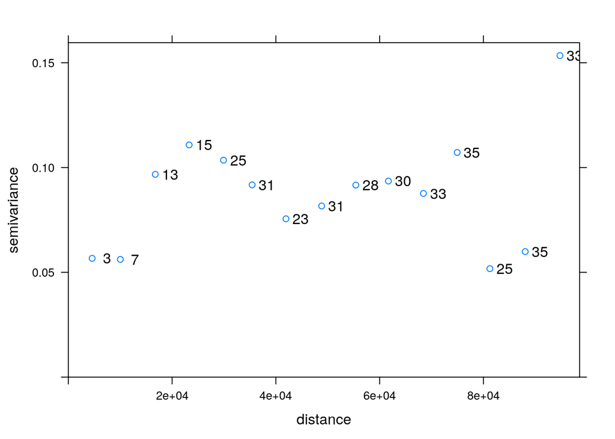

```r
plot(vsismolog, plot.numbers = T)
```

```r
vsismolog <- variogram(CDIlog~1, sismo[-3,], alpha = 0, tol.hor = 90/4)
vsismolog
```

| np | dist | gamma | dir.hor | dir.ver | id |
| --- | --- | --- | --- | --- | --- |
| 1 | 3483.671 | 0.02013436 | 0 | 0 | var1 |
| 1 | 16054.490 | 0.00000000 | 0 | 0 | var1 |
| 3 | 23355.594 | 0.16354323 | 0 | 0 | var1 |
| 5 | 30671.385 | 0.09243373 | 0 | 0 | var1 |
| 13 | 35856.397 | 0.11441264 | 0 | 0 | var1 |
| 4 | 42058.159 | 0.12191487 | 0 | 0 | var1 |
| 14 | 48475.921 | 0.11713332 | 0 | 0 | var1 |
| 7 | 55430.965 | 0.08257598 | 0 | 0 | var1 |
| 8 | 61727.363 | 0.07117756 | 0 | 0 | var1 |
| 7 | 68425.528 | 0.15423133 | 0 | 0 | var1 |

[output cut: 4 more lines]

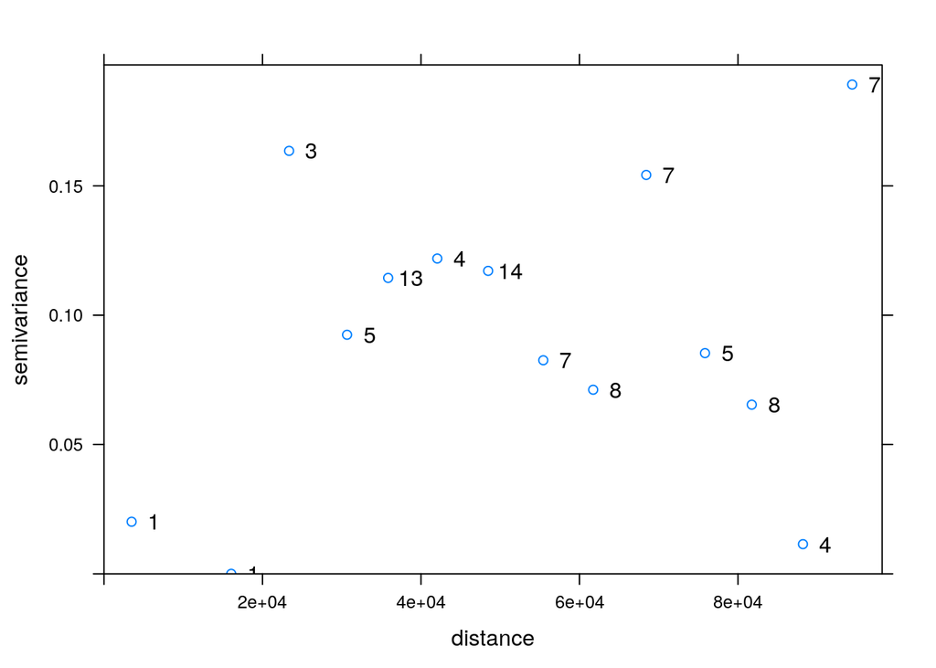

```r
plot(vsismolog, plot.numbers = T)
```

## 3 Variogramas modelo

```r
vsismo_m <- fit.variogram(vsismo, vgm(model = "Sph", range = 20000))
vsismo_m
```

| model | psill | range | kappa | ang1 | ang2 | ang3 | anis1 | anis2 |
| --- | --- | --- | --- | --- | --- | --- | --- | --- |
| Sph | 0.6698106 | 7552.753 | 0.5 | 0 | 0 | 0 | 1 | 1 |

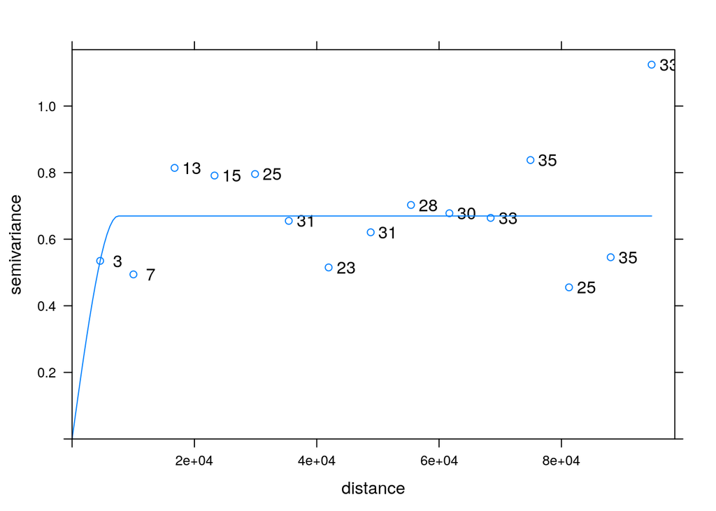

```r
plot(vsismo, vsismo_m, plot.numbers = T)
```

```r
vsismolog_m <- fit.variogram(vsismolog, vgm(model = "Wav", range = 15000))
vsismolog_m
```

| model | psill | range | kappa | ang1 | ang2 | ang3 | anis1 | anis2 |
| --- | --- | --- | --- | --- | --- | --- | --- | --- |
| Wav | 0.1048178 | 15000 | 0.5 | 0 | 0 | 0 | 1 | 1 |

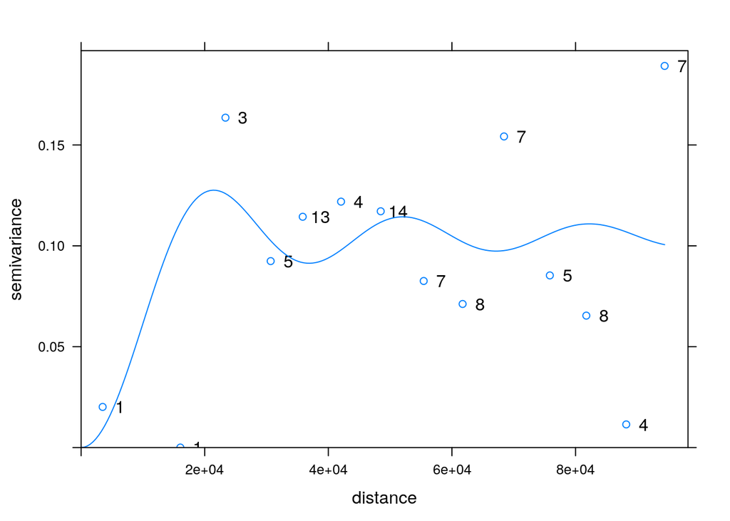

```r
plot(vsismolog, vsismolog_m, plot.numbers = T)
```

```r
vsismolog_m <- fit.variogram(vsismolog, vgm(model = "Exp", range = 30000))
vsismolog_m
```

| model | psill | range | kappa | ang1 | ang2 | ang3 | anis1 | anis2 |
| --- | --- | --- | --- | --- | --- | --- | --- | --- |
| Exp | 0.1179361 | 16212.96 | 0.5 | 0 | 0 | 0 | 1 | 1 |

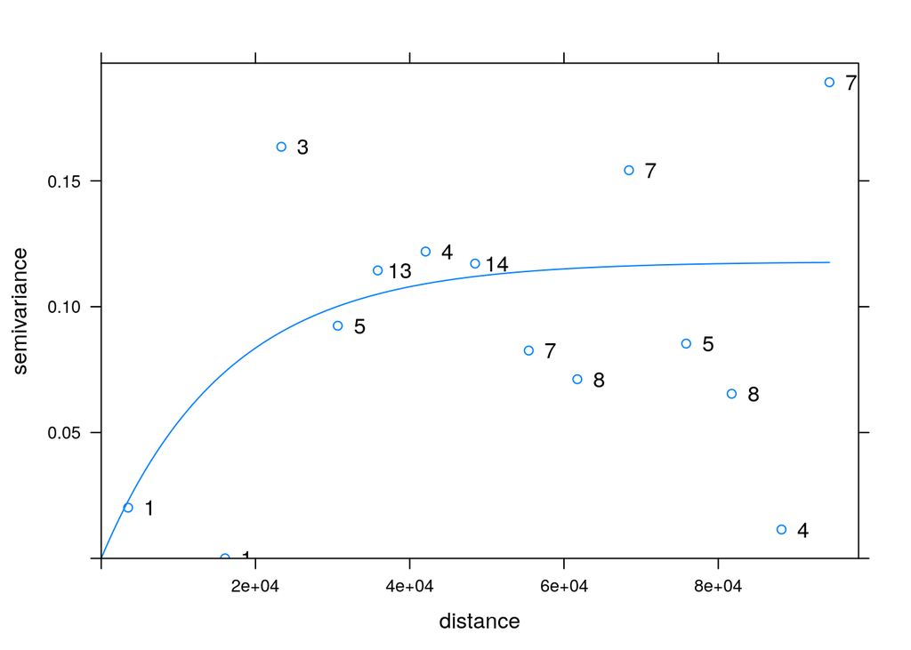

```r
plot(vsismolog, vsismolog_m, plot.numbers = T)
```

### Interpolación por kriging ordinario

Antes de realizar la interpolación, necesitamos una cuadrícula que “llenaremos” con las predicciones. Creemos una cuadrícula para RD, de resolución, 1x1km.

```r
library(stars)
grd <- st_bbox(prov) %>%
  st_as_stars(dx = 1000) %>% #100 metros=1km de resolución espacial
  st_set_crs(crswgs84utm) %>%
  st_crop(prov)
grd
```

```
## stars object with 2 dimensions and 1 attribute
## attribute(s):
##     values
##  Min.   :0
##  1st Qu.:0
##  Median :0
##  Mean   :0
##  3rd Qu.:0
##  Max.   :0
##  NA's   :58017
## dimension(s):
##   from  to  offset delta                       refsys point values
## x    1 390  182216  1000 +proj=utm +zone=19 +datum...    NA   NULL [x]
## y    1 272 2205216 -1000 +proj=utm +zone=19 +datum...    NA   NULL [y]
```

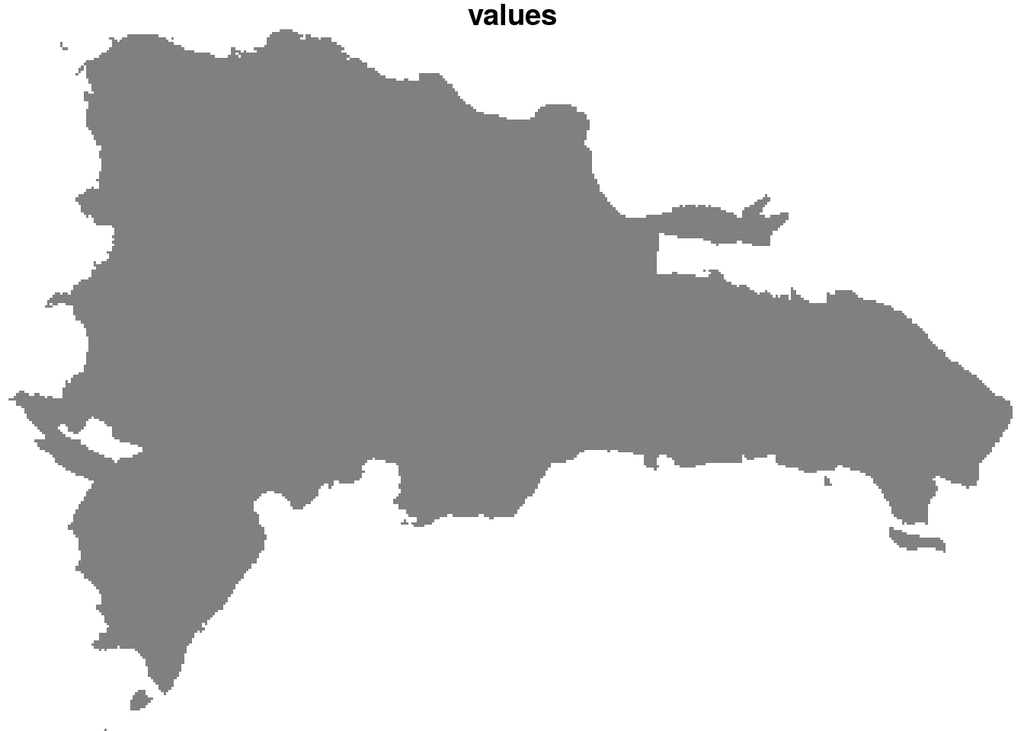

```r
plot(grd)
```

Interpolación de los datos

```r
ik <- krige(formula = CDIlog~1, locations = sismo, newdata = grd, model = vsismolog_m)
```

```
## [using ordinary kriging]
```

```r
ik
```

```
## stars object with 2 dimensions and 2 attributes
## attribute(s):
##    var1.pred       var1.var
##  Min.   :0.04    Min.   :0.00
##  1st Qu.:0.98    1st Qu.:0.08
##  Median :1.02    Median :0.11
##  Mean   :1.02    Mean   :0.10
##  3rd Qu.:1.06    3rd Qu.:0.12
##  Max.   :1.46    Max.   :0.12
##  NA's   :58017   NA's   :58017
## dimension(s):
##   from  to  offset delta                       refsys point values
## x    1 390  182216  1000 +proj=utm +zone=19 +datum...    NA   NULL [x]
## y    1 272 2205216 -1000 +proj=utm +zone=19 +datum...    NA   NULL [y]
```

```r
summary(as.vector(exp(ik$var1.pred)))
```

```
##    Min. 1st Qu.  Median    Mean 3rd Qu.    Max.    NA's
##    1.04    2.67    2.77    2.80    2.88    4.31   58017
```

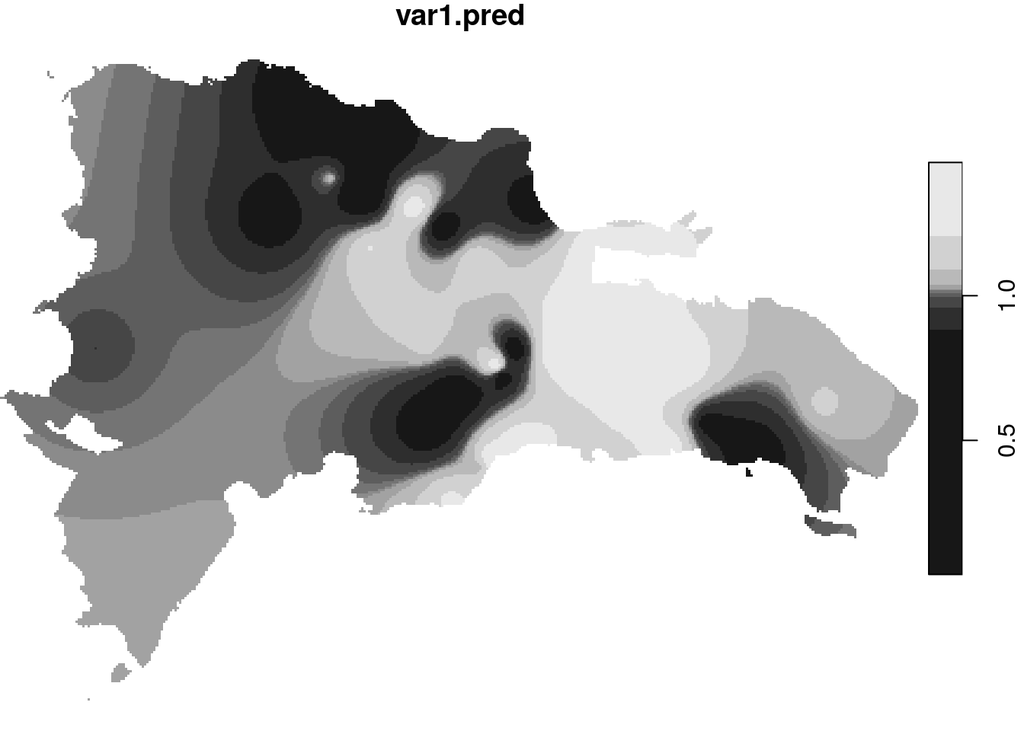

```r
plot(ik)
```

Utilicemos ggplot para representar el objeto resultante

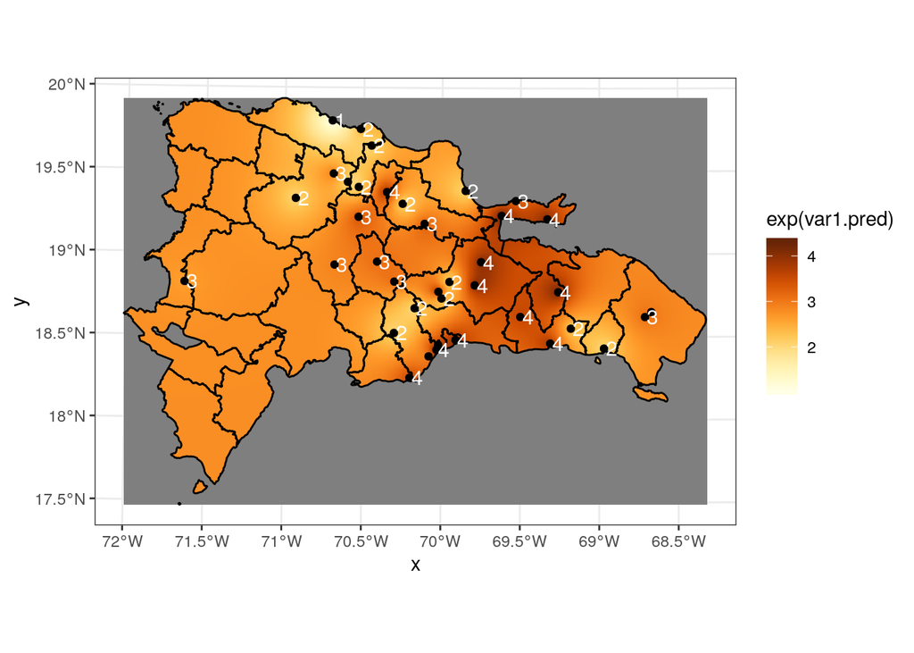

```r
ggplot() +
  geom_stars(data = ik, aes(fill = exp(var1.pred), x = x, y = y)) +
  scale_fill_gradientn(colours = brewer.pal(9, 'YlOrBr')) +
  geom_sf(data = st_cast(prov, "MULTILINESTRING")) +
  geom_sf(data = sismo) +
  geom_sf_text(data = sismo, aes(label=round(exp(CDIlog),0)), col = 'white', check_overlap = T, size = 4, nudge_x = 5000) +
  theme_bw()
```

# Referencias

[1]-Material de Apoyo de la asignatura Analisis Espacial de la Maestria en Teledeteccion y Ciencias Gegraficas de Escuela de Ciencias Geofrafica de la Universidad Autonoma de Santo Domingo, impartida por el Maestro José Ramon Martinez Beltra.

[2]- https://earthquake.usgs.gov/earthquakes/eventpage/us1000ehsg/dyfi/intensity